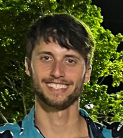

# David Gonilski-Pacin

## Bio

I am Molecular Biologist graduated in Buenos Aires University (UBA), Argentina. Currently I work on the [Biomedicine Institute of Buenos Aires](http://ibioba-mpsp-conicet.gov.ar/index.php/en/).

## Education

Selection of PhD courses taken (final grade): • Functional Genomics, School of Exact and Natural Sciences, University of Buenos Aires. (10/10). • Biological Instrumentation, School of Exact and Natural Sciences, University of Buenos Aires. (9/10). • Python programming course. School of Science and Technology, University of San Martín (UNSAM). (9/10). • Advanced Topics in RNA Cell Biology, School of Exact and Natural Sciences, University of Buenos Aires. (10/10). 2012-2019: Licenciatura (seven-year degree equivalent to Bachelor and Master combined) in Biological Sciences, School of Exact and Natural Sciences, University of Buenos Aires (Final Grade Point Average: 8.72/10). Thesis/Dissertation: “Functional and molecular characterization of the interaction of RSUME and mutants typical of VHL disease and its implications for VEGF overexpression and tumor vascularization” (grade: 10/10). Selection of elective courses taken (final grade):  
• Molecular Biology (10/10) • Genetic Engineering (8/10) • Introduction to Molecular Physiology (10/10) • Biological Chemistry II A (9/10) • Industrial Biotechnology and Applied Microbiology (10/10) 2007-2011: High School Degree - Carlos Pellegrini High School of Commerce, University of Buenos Aires - Specialization degree in commerce.

2021-present: Teaching as chief of practical applications, University of Jose C. Paz (paid position). Courses taught: Biostatistics and Demography, Microbiology and Parasitology. 2019-2021: Teaching assistant, Department of Biological Chemistry, School of Exact and Natural Sciences, University of Buenos Aires (paid position obtained through public contest). Courses taught: Introduction to Molecular Bioinformatics, Biological Chemistry. 2019-2020: Teaching assistant, Department of Physiology and Molecular and Cell Biology, School of Exact and Natural Sciences, University of Buenos Aires (paid position obtained through public contest). Courses taught: Genetics I.

## Works

These are some works i have been involved in:

**[Expression of RSUME is Associated With Poor Prognosis in Clear Cell Renal Carcinoma: Involvement of ROS Related Metabolism](https://www.sciencedirect.com/science/article/pii/S1558767323000678?casa_token=3_WXMMbAo9EAAAAA:CrOUVzqr_Flu8_l4UI54mkudacVHV5ObrPX6JgVrX8FsNmlmWYtXxiUrmKsxuKlQTo293Dnp-A)** | David Gonilski Pacin, Nicolás Ciancio del Giudice, Belén Elguero, Eduardo Arzt. Clinical Genitourinary Cancer (2023)

**[Impact of RSUME Actions on Biomolecular Modifications in Physio-Pathological Processes](https://www.frontiersin.org/articles/10.3389/fendo.2022.864780/full)** | Mariana Fuertes, Belén Elguero, David Gonilski-Pacin, …, Eduardo Arzt “Impact of RSUME Actions on Biomolecular Modifications in Physio-Pathological Processes”. Review article in Frontiers in Endocrinology (2022).

**[von Hippel-Lindau mutants in renal cell carcinoma are regulated by increased expression of RSUME](https://www.nature.com/articles/s41419-019-1507-3)** | Lucas Tedesco, Belen Elguero, David Gonilski Pacin, …, Eduardo Arzt. “von Hippel-Lindau mutants in renal cell carcinoma are regulated by increased expression of RSUME”. Cell Death & Disease (2019)

**[Mass Spectrometry-Based Metabolic Fingerprinting Contributes to Unveil the Role of RSUME in Renal Cell Carcinoma Cell Metabolism](https://pubs.acs.org/doi/full/10.1021/acs.jproteome.0c00655)** | Manuela Martinefski, Belen Elguero, María Knott, David Gonilski Pacin, …, Eduardo Arzt, María Eugenia Monge. Journal of Proteome Research (2021).

## Interests

I love soccer, Messi and the mate.